# Project 1: Test a Perceptual Phenomenon

Rashid Kazmi

13/02/2017

# Statistics: The Science of Decisions

## Background

In a Stroop task, participants are presented with a list of words, with each word displayed in a color of ink. The participant’s task is to say out loud the color of the ink in which the word is printed. The task has two conditions: a congruent words condition, and an incongruent words condition. In the congruent words condition, the words being displayed are color words whose names match the colors in which they are printed: for example RED, BLUE. In the incongruent words condition, the words displayed are color words whose names do not match the colors in which they are printed: for example PURPLE, ORANGE. In each case, we measure the time it takes to name the ink colors in equally-sized lists. Each participant will go through and record a time from each condition.

```r
# Install these packages if they are missing
library(knitr)
library(readr)
library(tidyr)
library(dplyr)
library(ggplot2)
library(ggthemes)
```

```r
# Read in Data
stroop_data <- read_csv("stroopdata.csv")
# View data
head(stroop_data)
```

```
## # A tibble: 6 × 2
##   Congruent Incongruent
##       <dbl>       <dbl>
## 1    12.079      19.278
## 2    16.791      18.741
## 3     9.564      21.214
## 4     8.630      15.687
## 5    14.669      22.803
## 6    12.238      20.878
```

```r
tail(stroop_data)
```

```
## # A tibble: 6 × 2
##   Congruent Incongruent
##       <dbl>       <dbl>
## 1    11.344      17.425
## 2    12.369      34.288
## 3    12.944      23.894
## 4    14.233      17.960
## 5    19.710      22.058
## 6    16.004      21.157
```

```r
# Check structure of the data
str(stroop_data)
```

```
## Classes 'tbl_df', 'tbl' and 'data.frame':    24 obs. of  2 variables:
##  $ Congruent  : num  12.08 16.79 9.56 8.63 14.67 ...
##  $ Incongruent: num  19.3 18.7 21.2 15.7 22.8 ...
##  - attr(*, "spec")=List of 2
##   ..$ cols   :List of 2
##   .. ..$ Congruent  : list()
##   .. .. ..- attr(*, "class")= chr  "collector_double" "collector"
##   .. ..$ Incongruent: list()
##   .. .. ..- attr(*, "class")= chr  "collector_double" "collector"
##   ..$ default: list()
##   .. ..- attr(*, "class")= chr  "collector_guess" "collector"
##   ..- attr(*, "class")= chr "col_spec"
```

```r
# Reshape data in long format
stroop_data_long <- stroop_data %>%
                    gather(key = Condition, value = ResponseTime)
```

# Variables

- The independent variable is whether the words shown are congruent with the ink colors or if they are incongruent with ink colors.
- Condition: Independent Variable
  - Congruent
  - Incongruent
- ResponseTime: Dependent Variable

# Dependent-Samples t-tests

We can formulate hypothesis that there is a difference between the time used to recognise colours under congruent words condition and incongruent words condition, namely, the Stroop Effect is in existence. Specifically, here we referring to the population means of congruence words condition and incongruence words condition - average times for the respective condition to recognise the colours. By comparing these means directly, we’ll be able to tell whether there is a difference between the the two conditions’ colour recognition times.

$$H_0 : \mu_2 - \mu_1= 0$$

$$H_1 : \mu_2 - \mu_1 \neq 0$$

— Null Hypothesis $H_0 : \mu_2 - \mu_1= 0$ :: The group population mean of the differences ($\mu_2 - \mu_1= 0$) equals the zero.

— Alternative Hypothesis $H_1 : \mu_2 - \mu_1 \neq 0$:: The group population mean of the difference ($\mu_2 - \mu_1 \neq 0$) does not equal to zero.

## Statistical test

In this study researcher compares two samples that are dependent. They are dependent because the same subject are assigned to two conditions in random order. Thus, this is within subject design. When we have these within subject designs, we have parired data. So column of x<sub>i</sub>’s would corresponds to the variable measurement of one condition. And then the y<sub>i</sub> values would corresponds to a second treatment. And then, what we want to do is look at the difference between these values, We’ll call this D sub i. And thats just the x values minus the y values. Or it could be be the opposite. We are really just concerned with absolute difference. Now we follow the same procedure as we did before with one sample t-test, except we used values of D.

However, it wouldn’t be possible to do the experiment with all potential subjects in the world, so we need to work with the sample we have on hand to make inference about the population means, i.e., to use the observation means, sd and other statistics to infer about the population means. In this case, the observation is the difference between the two conditions’ times. With this new data, we can construct new statistics such as means and standard errors.

To achieve this, We can use a two-sided paired student t-test to verify. This is because: one, we need to address the uncertainty in sample standard error resulted from the unknown population standard deviation; two, we are comparing the means of two groups that are dependent; three, the same subject is involved under both conditions.

We know the formula for the one-sample t-test:

$$t=\frac{\bar{X} - \mu_{\bar(X)}}{s_{\bar{X}}}$$

Difference scores are symbolised with D instead of X. So if you were to conduct a one-sample t-test with difference scores, the formula would be:

$$t=\frac{\bar{D}}{s_{\bar{D}}}$$

This means that the observed t is equal to the sample mean of the difference scores divided by the estimated standard error of the difference scores. What is special about this formula is that it contains no population parameters, only sample statistics. It is for this reason that paired-samples t-tests are widely used: There is no need to know any population parameters in advance.

$$t= \frac{\mu_D - 0}{S/\sqrt{n}}$$

# Descriptive Statistics

```r
# Summarise data by group
sumstat <- stroop_data_long %>%
        group_by(Condition) %>%
        summarise(N = length(ResponseTime),
                 Mean = mean(ResponseTime),
                 SD = sd(ResponseTime),
                 SE = SD/sqrt(N))

# Display sumstat
library(knitr)

# Summarise whole data set
total_sumstat <- stroop_data_long %>%
              summarise(Condition = "Total",
                        N = length(ResponseTime),
                        Mean = mean(ResponseTime),
                        SD = sd(ResponseTime),
                        SE = SD/sqrt(N))

# Now we combine data into one object
combined_sumstat <- rbind(sumstat, total_sumstat)
```

```r
# Make Table
  knitr::kable(combined_sumstat,
               digits = 2,
               caption = "Descriptive Statistics for ResponseTime")
```

Descriptive Statistics for ResponseTime

| Condition | N | Mean | SD | SE |
| --- | --- | --- | --- | --- |
| Congruent | 24 | 14.05 | 3.56 | 0.73 |
| Incongruent | 24 | 22.02 | 4.80 | 0.98 |
| Total | 48 | 18.03 | 5.80 | 0.84 |

# Data Viusalistaion

## Bar Plot

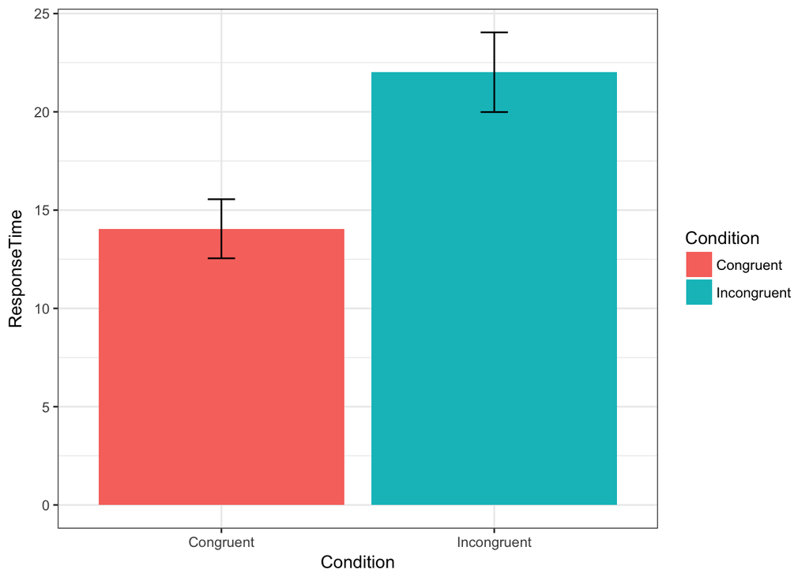

```r
  ggplot(data = stroop_data_long, aes(x = Condition, y = ResponseTime, fill =  Condition)) +
        stat_summary(fun.y = "mean", geom = "bar") +
        stat_summary(fun.data = "mean_cl_normal", geom = "errorbar", width = 0.1) +
        theme_bw()
```

## Boxplot

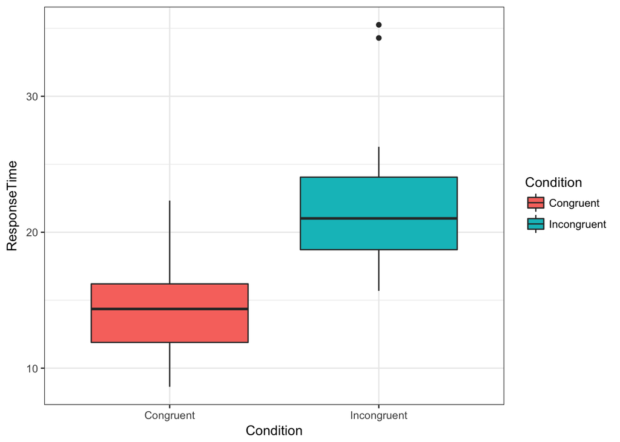

```r
  ggplot(data = stroop_data_long, aes(x = Condition, y = ResponseTime, fill = Condition)) +
      geom_boxplot() +
      theme_bw()
```

## Combined Violin and Notched Boxplot

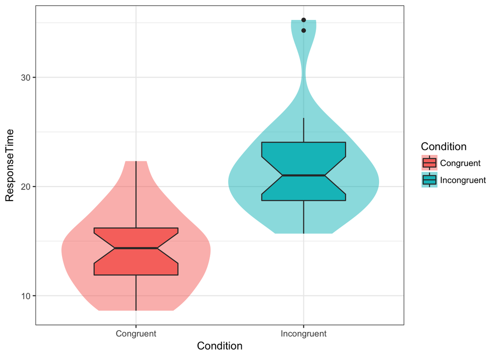

Combined Violin and Notched Boxplot: As we see, the notches for the congruent and incongruent words condition don’t overlap, so there is strong evidence to suggest that their medians are significantly different.

```r
ggplot(data = stroop_data_long, aes(x = Condition, y = ResponseTime, fill = Condition)) +
      geom_violin(alpha = 0.5, color = NA) +
      geom_boxplot(notch = TRUE, width = 0.5) +
      theme_bw()
```

## Dot Plot Point Range

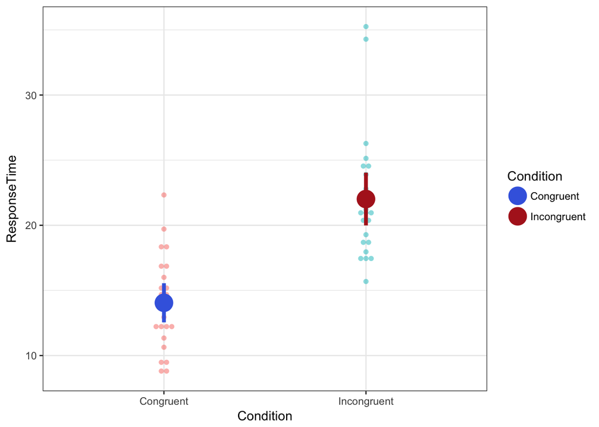

Dot Plot with PointRange Showing Means and 95% CI: Plotting points summarising the data to plot the means of the two condition with an estimate of 95% confidence interval representing the precision of an estimate. A 95% confidence interval means that 95% of the time, the population mean will be within that interval and 5% of the time, the population mean will be outside of that interval. This means you can be 95% confident that the population mean is within your confidence interval.

```r
library(ggplot2)
library(ggthemes)

ggplot(data = stroop_data_long, aes(x = Condition, y = ResponseTime, fill = Condition)) +
    geom_dotplot(binaxis = "y", stackdir = "center",binwidth = .4, alpha = 0.5, color = NA) +
    stat_summary(fun.data = "mean_cl_normal", geom = "pointrange", width = 0.1,
                                         color = c("royalblue","firebrick"), lwd = 1.5) +
    theme_bw()
```

```r
# H0:μ2−μ1 = 0
# H1:μ2−μ1 ≠ 0

# the null value
mu_diff <- 0
# add a new diff column
dat.diff <- mutate(stroop_data, diff = Congruent - Incongruent)
# grab all the diff values into a vector
diff <- dat.diff$diff
# sample sd
sigma <- sd(diff)
# sample mean
diff_bar <- mean(diff)
# sample size
n <- length(diff)
# degree of freedom
DF <- n - 1
# standard error
SE <- sigma/sqrt(n)
# Calculate the T-statistic:
T <- (diff_bar- mu_diff)/SE; T
```

```
## [1] -8.020707
```

```r
# Calculate the p-value
p_value <- pt(T, df = DF, lower.tail = TRUE) * 2; p_value
```

```
## [1] 4.103001e-08
```

```r
# Build the confidence interval based on 5% confidence level
diff_bar + c(1, -1) * qt(.975, df = DF, lower.tail = FALSE) * SE
```

```
## [1] -10.019028  -5.910555
```

# Running the Dependent Samples t-test

```r
ttest <- t.test(ResponseTime ~ Condition, data = stroop_data_long,
                                paired = TRUE, mu = 0, conf.level = 0.95)

tvalue <- ttest$statistic %>%
          formatC(digit = 2, format = "f")


pvalue <- ttest$p.value %>%
          formatC(digit = 2, format = "f")

df <- ttest$parameter

ttest
```

```
##
##  Paired t-test
##
## data:  ResponseTime by Condition
## t = -8.0207, df = 23, p-value = 4.103e-08
## alternative hypothesis: true difference in means is not equal to 0
## 95 percent confidence interval:
##  -10.019028  -5.910555
## sample estimates:
## mean of the differences
##               -7.964792
```

```r
tvalue
```

```
##       t
## "-8.02"
```

```r
df
```

```
## df
## 23
```

```r
pvalue
```

```
## [1] "0.00"
```

# Results